# Nodule_trapping_species_statistics

2026-02-23

# Nodule trapping statistics

This document contains the code for running the statistical analyses and data visualization for the nodule trapping data.

# Load required libraries

```r
library(lme4)
library(phyloseq)
library(car)
library(emmeans)
library(ggplot2)
library(patchwork)
library(vegan)
library(dplyr)
library(tidyr)
library(kableExtra)
library(tibble)
library(rcartocolor)
```

# Prepare a phyloseq object

Generate a phyloseq object where each sample is one soil - host combination (so 36 total samples), and the abundance of each species per sample is provided.

```r
# Load the isolate source information
isolates <- read.table("isolate_source.txt",
                       header = TRUE, row.names = NULL)

# Count species abundance per sample
isolates.grouped <- isolates %>%
  group_by(Sample, Species_classification) %>%
  summarize(counts = n())
isolates.grouped.matrix <- isolates.grouped %>%
  pivot_wider(
    names_from = Sample,
    values_from = counts
  ) %>%
  column_to_rownames("Species_classification") %>%
  as.matrix()

# Create the final OTU table
otumat <- isolates.grouped.matrix
otumat[is.na(otumat)] <- 0

# Load the taxonomy table
taxmat <- as.matrix(read.table("isolate_taxonomy.txt",
                        header = TRUE, row.names = 1))

# Load the sample metadata
metadata <- read.table("sample_metadata.txt",
                       header = TRUE, row.names = 1)

# Combine the data into a phyloseq object
OTU <- otu_table(otumat, taxa_are_rows = TRUE)
TAX <- tax_table(taxmat)
META <- sample_data(metadata)
ps <- phyloseq(OTU, TAX, META)

# Convert species abundances to percentages
ps.rel <- transform_sample_counts(ps, function(x) x / sum(x))
```

# Statistical analysis of soil and trapping host on the composition of the recovered rhizobiial population

Now calculate Bray-Curtis distances and use to evaluate the impact of soil and host on the composition of the recovered rhizobial communities.

```r
# Calculate the bray curtis distances
dist_bc <- phyloseq::distance(ps.rel, method = "bray")

# Extract sample data
meta <- data.frame(sample_data(ps.rel))
```

First test based on soil.

```r
# Perform a permutation test to test if the data meet the assumptions of PERMANOVA in terms of soil
beta.bray <- betadisper(dist_bc, meta$Soil, type = "centroid", bias.adjust = TRUE)
permdisp <- permutest(beta.bray, pairwise = TRUE, permutations = 10000)
permdisp
```

[output not shown]

Now test based on host.

```r
# Perform a permutation test to test if the data meet the assumptions of PERMANOVA in terms of host
beta.bray <- betadisper(dist_bc, meta$Host, type = "centroid", bias.adjust = TRUE)
permdisp <- permutest(beta.bray, pairwise = TRUE, permutations = 10000)
permdisp
```

[output not shown]

Dispersion is not statistically different for the host genotype but does differ between soils, which means the results of PERMANOVA are not reliable. Nevertheless, run the PERMANOVA (accounting for soil and host) and pair it with a PCoA to visualize the data.

```r
# Run the PERMANOVA test
adonis.bray <- adonis2(dist_bc ~ Soil + Host, data = meta, permutations = 10000, by = "margin")
as.data.frame(adonis.bray)
```

```
##          Df   SumOfSqs         R2          F     Pr(>F)
## Soil      8  8.4257024 0.75726459 10.4901750 0.00009999
## Host      3  0.2911966 0.02617146  0.9667891 0.47355264
## Residual 24  2.4095982 0.21656395         NA         NA
## Total    35 11.1264972 1.00000000         NA         NA
```

Based on the PERMANOVA, there is a strong effect of soil but no effect of host genotype.

Now run a capscale analysis since it is less sensitive to differences in dispersion and thus should be more appropriate than PERMANOVA in this case.

```r
# Set the formula for the model
class(fo <- dist_bc ~ meta$Soil + meta$Host)
```

```
## [1] "formula"
```

```r
# Run the capscale analysis followed by an ANOVA
pso_cap <- ordinate(ps.rel, "CAP", "bray", formula=fo)
anova(pso_cap, by = "margin", type = 2)
```

```
## Permutation test for capscale under reduced model
## Marginal effects of terms
## Permutation: free
## Number of permutations: 999
##
## Model: capscale(formula = OTU ~ meta$Soil + meta$Host, data = data, distance = distance)
##           Df SumOfSqs      F Pr(>F)
## meta$Soil  8   8.6141 7.9921  0.001 ***
## meta$Host  3   0.3916 0.9690  0.465
## Residual  24   3.2335
## ---
## Signif. codes:  0 '***' 0.001 '**' 0.01 '*' 0.05 '.' 0.1 ' ' 1
```

As before, the soil had a statistically significant effect on the recovered rhizobial population whereas the host genotype did not.

# Prepare figures

Create a multi-panel figure showing the diversity of rhizobia recovered according to soil and trapping cultivar.

Start by creating an ordination plot from the PCoA data, although will ultimately use the ordination plot based on the capscale analysis in the manuscript.

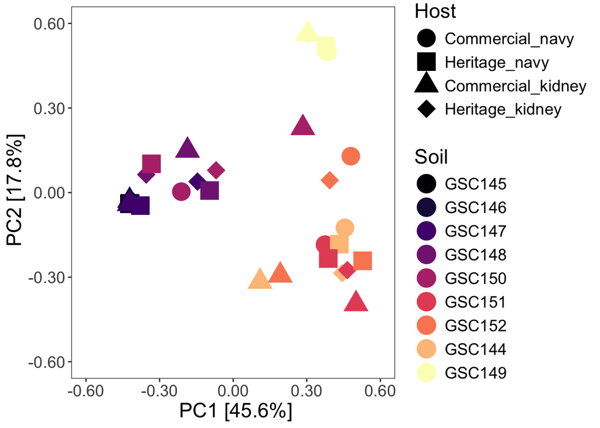

```r
# Create a PCoA plot
sample_data(ps.rel)$Soil <- factor(sample_data(ps.rel)$Soil,
                                        levels = c("GSC145", "GSC146", "GSC147", "GSC148",
                                                   "GSC150", "GSC151", "GSC152", "GSC144",
                                                   "GSC149"))
sample_data(ps.rel)$Host <- factor(sample_data(ps.rel)$Host,
                                        levels = c("Commercial_navy", "Heritage_navy",
                                                   "Commercial_kidney", "Heritage_kidney"))
pso <- ordinate(ps.rel, "PCoA", "bray")
var_explained <- pso$values$Relative_eig * 100
ordplot5 <- plot_ordination(ps.rel, pso, type="samples",
                            color="Soil", shape="Host",
                            axes = c(1,2))
p.beta.pcoa <- ordplot5 +  theme_bw() + theme(text = element_text(size = 17), aspect.ratio = 1) +
  geom_point(size = 7) +
  scale_colour_viridis_d(option="magma") +
  scale_shape_manual(values=c(16,15,17,18)) +
  theme_bw() +
  theme(text = element_text(size = 17),
        panel.grid.major = element_blank(),
        panel.grid.minor = element_blank(),
        legend.position = "right") +
  labs(x = paste0(" PC1 [", round(var_explained[1], 1), "%]"),
       y = paste0(" PC2 [", round(var_explained[2], 1), "%]")) +
  scale_x_continuous(lim=c(-0.60,0.60), breaks=c(-0.60,-0.30,0.00,0.30,0.60),
                     labels = function(x) sprintf("%.2f", x)) +
  scale_y_continuous(lim=c(-0.60,0.60), breaks=c(-0.60,-0.30,0.00,0.30,0.60),
                     labels = function(x) sprintf("%.2f", x))
p.beta.pcoa
```

Now make an ordination plot based on the capscale analysis.

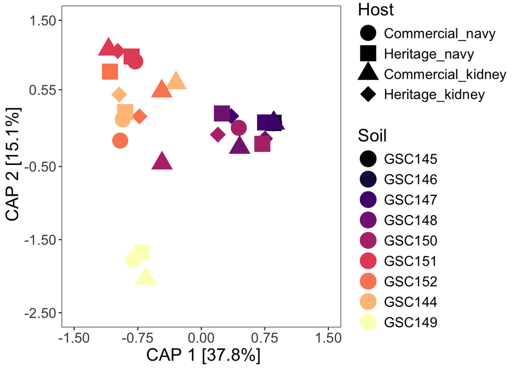

```r
# Get the relative eigenvalues
all_eig <- eigenvals(pso_cap)
rel_eig <- all_eig / sum(all_eig)
var_explained <- round(rel_eig * 100, 1)

# Plot the capscale results
ordplot5 <- plot_ordination(ps.rel, pso_cap, type="samples", color="Soil",
                            shape="Host", axes = c(1,2))
p.beta.cap <- ordplot5 +  theme_bw() + theme(text = element_text(size = 17), aspect.ratio = 1) +
  geom_point(size = 7) +
  scale_colour_viridis_d(option="magma") +
  scale_shape_manual(values=c(16,15,17,18)) +
  theme_bw() +
  theme(text = element_text(size = 17),
        panel.grid.major = element_blank(),
        panel.grid.minor = element_blank(),
        legend.position = "right") +
  labs(x = paste0(" CAP 1 [", round(var_explained[1], 1), "%]"),
       y = paste0(" CAP 2 [", round(var_explained[2], 1), "%]")) +
  scale_x_continuous(lim=c(-1.50,1.50), breaks=c(-1.50,-0.75,0.00,0.75,1.5),
                     labels = function(x) sprintf("%.2f", x)) +
  scale_y_continuous(lim=c(-2.50,1.50), breaks=c(-2.50,-1.50,-0.50,0.550,1.50),
                     labels = function(x) sprintf("%.2f", x))
p.beta.cap
```

Moving on, let’s make stacked bar plots, starting with a figure with the population broken down by original soil.

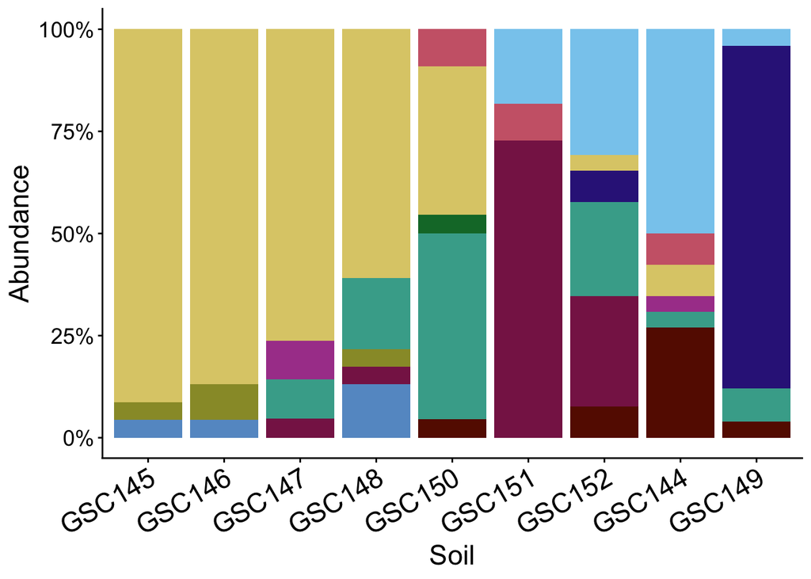

```r
# Sort by soil
isolates$Soil <- factor(isolates$Soil,
                        levels = c("GSC145", "GSC146", "GSC147", "GSC148",
                                   "GSC150", "GSC151", "GSC152", "GSC144",
                                   "GSC149"))
isolates$Host <- factor(isolates$Host,
                        levels = c("Commercial_navy", "Heritage_navy",
                                   "Commercial_kidney", "Heritage_kidney"))

# Create a barplot by soil
myColours <- carto_pal(12, "Safe")
soilp <- ggplot(isolates, aes(x=Soil, fill=Species_classification)) +
  geom_bar(position = "fill") +
  scale_y_continuous(labels = scales::percent) +
  xlab("Soil") +
  ylab("Abundance") +
  scale_fill_manual(values=c(myColours[1],myColours[2],myColours[3],myColours[4],
                             myColours[5],myColours[6],myColours[7],myColours[8],
                             myColours[9],myColours[10],myColours[11])) +
  theme_classic() +
  theme(text = element_text(size = 17),
        panel.grid.major = element_blank(),
        panel.grid.minor = element_blank(),
        legend.position = "none",
        axis.text.x = element_text(size = 17, angle = 30, hjust = 1, vjust=1))
soilp
```

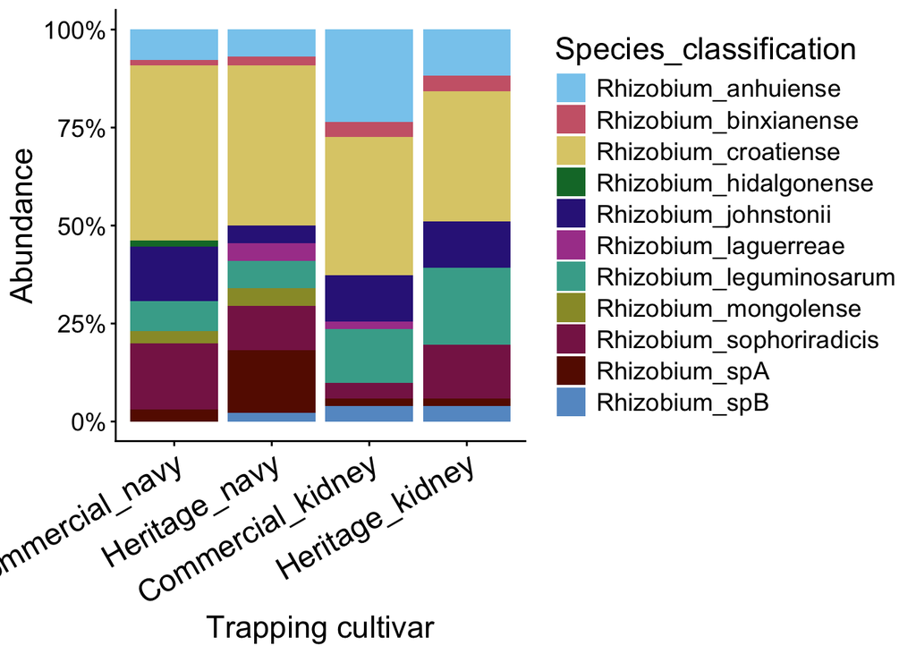

```r
 # Create a barplot by soil
myColours <- carto_pal(12, "Safe")
soilc <- ggplot(isolates, aes(x=Host, fill=Species_classification)) +
  geom_bar(position = "fill") +
  scale_y_continuous(labels = scales::percent) +
  xlab("Trapping cultivar") +
  ylab("Abundance") +
  scale_fill_manual(values=c(myColours[1],myColours[2],myColours[3],myColours[4],
                             myColours[5],myColours[6],myColours[7],myColours[8],
                             myColours[9],myColours[10],myColours[11])) +
  theme_classic() +
  theme(text = element_text(size = 17),
        panel.grid.major = element_blank(),
        panel.grid.minor = element_blank(),
        legend.position = "right",
        axis.text.x = element_text(size = 17, angle = 30, hjust = 1, vjust=1))
soilc
```

```r
# Save the figure
pdf('Nodule.trapping.pdf', width=9, height=18.25)
p.beta.cap / soilp + soilc + plot_layout(heights = c(1,1,1))
dev.off()
```